# Calcul d’IMC de patients diabéques et non-diabéques

2025-10-16

Voici notre base de données de patients diabétiques et non-diabétiques

```
##            nom   taille     poids diabete
## 1     patient1 1.627972  62.75802     non
## 2     patient2 1.763894  68.10204     non
## 3     patient3 1.882723  70.45261     non
## 4     patient4 1.672306  61.94566     non
## 5     patient5 1.542413  58.91899     non
## 6     patient6 1.779944  69.08081     non
## 7     patient7 1.762746  67.87909     non
## 8     patient8 1.709276  67.36576     non
## 9     patient9 1.767117  65.49244     non
## 10   patient10 1.622212  63.84692     non
## 11   patient11 1.563291  59.76274     non
## 12   patient12 1.815765  69.56096     non
## 13   patient13 1.575607  59.17244     non
## 14   patient14 1.752509  65.74481     non
```

[output cut: 186 more lines]

Questions :

1. Créer une fonction permettant de calculer l’imc

```r
Calcul_IMC <- function(poids, taille) {
  IMC <- poids/(taille*taille)
  return(IMC)
}
```

2. Calculer l’imc de chaque patient

```r
data_imc$IMC <- Calcul_IMC(data_imc$poids, data_imc$taille)
data_imc$IMC
```

```
##   [1] 23.67966 21.88846 19.87579 22.15029 24.76590 21.80443 21.84523 23.05765
##   [9] 20.97299 24.26190 24.45407 21.09825 23.83546 21.40628 21.18645 22.74011
##  [17] 21.83136 25.17748 23.88082 21.54026 22.66707 22.63330 23.28673 21.19788
##  [25] 22.45006 22.93611 21.17722 22.02716 24.64950 25.25998 23.32255 19.75301
##  [33] 23.73876 23.64770 21.70009 22.18926 21.43991 22.46256 22.97631 21.81962
##  [41] 23.16701 21.73995 23.17629 21.67646 23.23963 22.00850 22.16635 20.87393
##  [49] 20.27285 21.77818 20.89059 22.77511 23.53878 22.33689 24.06751 24.02983
##  [57] 23.78090 22.25551 20.42473 24.08848 22.88576 21.13785 21.68767 24.30625
##  [65] 22.21158 21.60938 22.89001 22.58975 22.06206 22.80119 20.60730 20.56239
##  [73] 24.20742 24.88918 22.51013 23.95030 25.33709 22.55203 22.78473 22.81854
##  [81] 23.14238 21.22838 20.50611 23.83477 23.69737 24.91694 22.76076 20.84287
##  [89] 22.88319 21.36465 23.40378 23.77420 21.70454 22.03942 24.98750 20.61578
##  [97] 24.01114 23.42274 20.27693 25.60984 34.62767 38.48041 31.75935 35.79662
## [105] 32.35642 28.57971 37.20145 30.46265 33.96616 31.16170 31.29528 37.51905
## [113] 32.19915 30.29733 31.15730 31.73458 34.02933 29.38518 31.23672 24.96404
## [121] 28.90716 31.02791 34.19247 31.76497 30.43263 33.23582 27.22999 30.02572
## [129] 31.74051 32.37827 34.84854 31.96890 34.25541 29.20168 33.95955 33.44520
## [137] 27.79129 32.31307 38.23299 36.08076 35.16352 29.37692 37.56696 32.25635
## [145] 32.47370 30.81850 35.89887 33.33868 31.02346 27.41189 35.77090 29.22431
## [153] 34.56197 32.86312 34.47988 28.38651 31.67244 32.33512 32.20506 30.74640
## [161] 34.97598 36.66642 33.18075 30.98359 36.96113 30.36576 32.28261 36.73925
## [169] 31.51526 28.21947 35.27513 32.06647 34.05487 31.66241 31.52619 31.70137
## [177] 31.33788 30.10395 29.15166 40.13414 28.10616 35.00028 34.07586 33.26080
## [185] 31.43491 41.16563 32.10216 34.44827 31.27431 29.66099 34.26983 30.47015
## [193] 34.68220 36.65719 35.66620 29.20516 31.44772 32.66075 29.11813 37.89066
```

3. Quel est le coefficient de corrélation entre le poids et la taille ?

```r
cor.test(data_imc$poids, data_imc$taille)
```

```
##
##  Pearson's product-moment correlation
##
## data:  data_imc$poids and data_imc$taille
## t = 3.357, df = 198, p-value = 0.0009447
## alternative hypothesis: true correlation is not equal to 0
## 95 percent confidence interval:
##  0.0964237 0.3592352
## sample estimates:
##       cor
## 0.2320602
```

Cette corrélation est-elle significative ?

Interprétation du test :

H0 : Le poids et la taille sont indépendants (hypothèse nulle)

H1 : Le poids et la taille sont corrélés (hypothèse alternative)

On rejette H0 (p-value<0.05) et H1 est validé. Donc, il existe une relation entre poids et taille.

A partir du résultat du test statistique, on peut en conclure que la corrélation entre le poids et la taille est statistiquement significative.

4. Représenter sur le même graphique la relation entre le poids et la taille pour chaque groupe de patients (diabétiques, non-diabétiques)

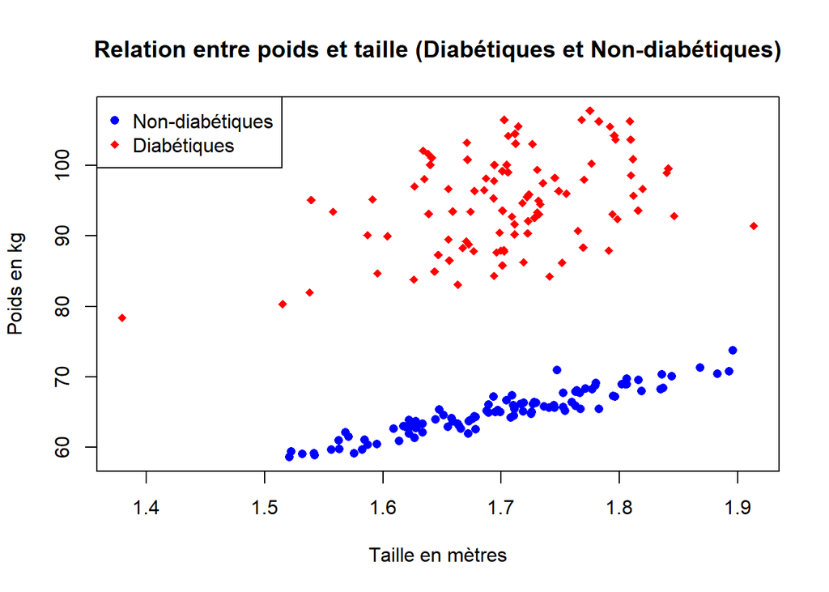

5. Représenter côte à côte les distributions (histogrammes) de l’imc pour chaque groupe de patients.

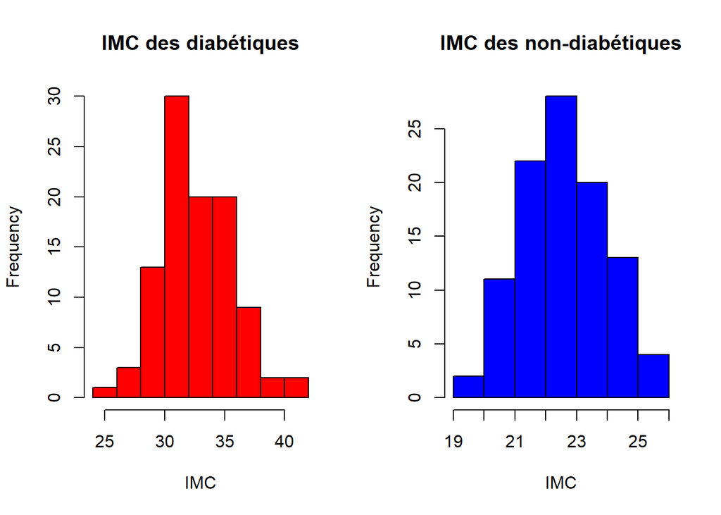

```r
# Création de deux graphiques côte à côte
par(mfrow = c(1, 2))
# Histogramme des diabétiques
hist(diabetiques$IMC,
     col = "red",
     main = "IMC des diabétiques",
     xlab = "IMC")
# Histogramme des non-diabétiques
hist(non_diabetiques$IMC,
     col = "blue",
     main = "IMC des non-diabétiques",
     xlab = "IMC")
```

6. La différence d’imc entre les groupes est-elle significative ?

Pour savoir si cette différence est statistiquement significative, on va effectuer un test stastistique. Cependant, plusieurs critères sont à valider avant de pourvoir réaliser le test. Tout d’abord, nos deux groupes doivent contenir un assez grand nombre de sujets à comparer (>30) et leurs distributions doivent suivre une loi normale. On sait que les 2 groupes contiennent chacun 100 patients. Un des critères est donc déja valide. Pour vérifier si nos deux groupes suivent une loi normale, on peut le vérifier avec un diagramme de normalité.

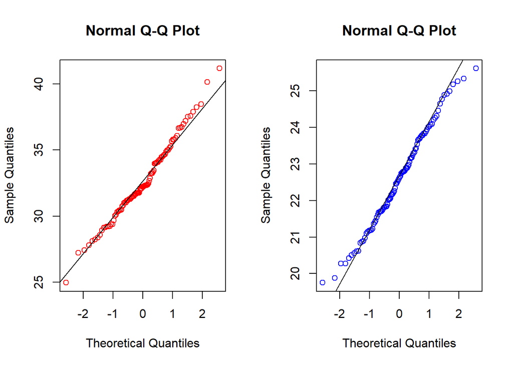

```r
# Affichage de mes graphiques côte à côte
par(mfrow= c(1,2))
# Diagramme des diabétiques
qqnorm(diabetiques$IMC, col = "red");qqline(diabetiques$IMC)
# Diagramme des non-diabétiques
qqnorm(non_diabetiques$IMC, col = "blue");qqline(non_diabetiques$IMC)
```

On constate sur les diagrammes des 2 groupes que les points sont majoritairement proches de la ligne droite. Cela signifit que les données suivent une distribution normale. Le second critère est également validé. Il ne reste qu’un dernier critère à valider pour effectuer notre test. Il faut que les variances soient identiques dans les deux groupes. Pour cela, on va faire un test d’égalité des variances.

```r
var.test(diabetiques$IMC, non_diabetiques$IMC)
```

```
##
##  F test to compare two variances
##
## data:  diabetiques$IMC and non_diabetiques$IMC
## F = 4.7753, num df = 99, denom df = 99, p-value = 1.255e-13
## alternative hypothesis: true ratio of variances is not equal to 1
## 95 percent confidence interval:
##  3.213045 7.097266
## sample estimates:
## ratio of variances
##           4.775336
```

Interprétation du test :

H0 : les variances sont égales (hypothèse nulle)

H1 : les variances ne sont pas égales (hypothèse alternative)

On rejette H0 (p-value<0.05) et H1 est validé. Donc, les variances des deux distributions ne sont pas égales.

Malgré que les variances des deux distributions ne soient pas égales, il est possible d’effectuer notre test statistique. Dans cette situation, on utlise un test de Welch pour comparer les moyennes.

```r
t.test(diabetiques$IMC, non_diabetiques$IMC, var.equal=FALSE)
```

```
##
##  Welch Two Sample t-test
##
## data:  diabetiques$IMC and non_diabetiques$IMC
## t = 30.621, df = 138.72, p-value < 2.2e-16
## alternative hypothesis: true difference in means is not equal to 0
## 95 percent confidence interval:
##   9.352608 10.643796
## sample estimates:
## mean of x mean of y
##  32.60319  22.60499
```

Interprétation du test :

H0 : les moyennes sont égales (hypothèse nulle)

H1 : les moyennes ne sont pas égales (hypothèse alternative)

On rejette H0 (p-value<0.05) et H1 est validé. Donc, les moyennes des deux distributions ne sont pas égales.

A partir du résultat du test statistique, on peut en conclure que la différence d’imc entre les deux groupes est significative.